# BACS HW4

##### 2021/03/18

(Give assistance: 106070020)

### 【Question 1】

#### a. Create a normal distribution (mean=940, sd=190) and standardize it.

```r
# define standardize function
standardized <- function(numbers){
  numbers <- (numbers-mean(numbers))/sd(numbers)

  return(numbers)
}
```

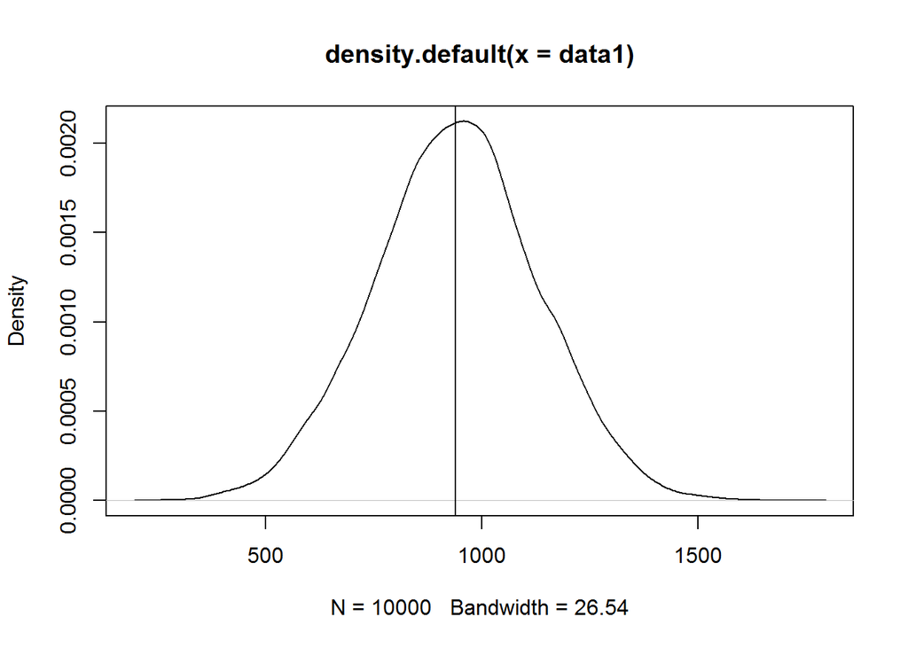

```r
# prepare the raw data and plot the distribution of it
data1 <- rnorm(10000, mean=940, sd=190)
plot(density(data1))
abline(v=mean(data1))
```

```r
# standardize the raw data
rnorm_std <- standardized(data1)
```

**i) What should we expect the mean and standard deviation of rnorm_std to be, and why?**

```r
# Get the mean of rnorm_std
mean(rnorm_std)
```

```
## [1] 4.672841e-17
```

```r
# Get the standard deviaiton of rnorm_std
sd(rnorm_std)
```

```
## [1] 1
```

**→**

We expect to get mean 0 and standard deviation 1.

The formula of standardization is z = (x − μ)/σ.

The whole point of this is to convert the data set to a new one with mean 0 and standard deviation 1. As a result, the mean of rnorm_std will be 0 and the standard deviation of rnorm_std will be 1.

The little difference on mean above (close to 0 but not 0) is caused by the limitation of R in recording the number of digits.

**ii) What should the distribution (shape) of rnorm_std look like, and why?**

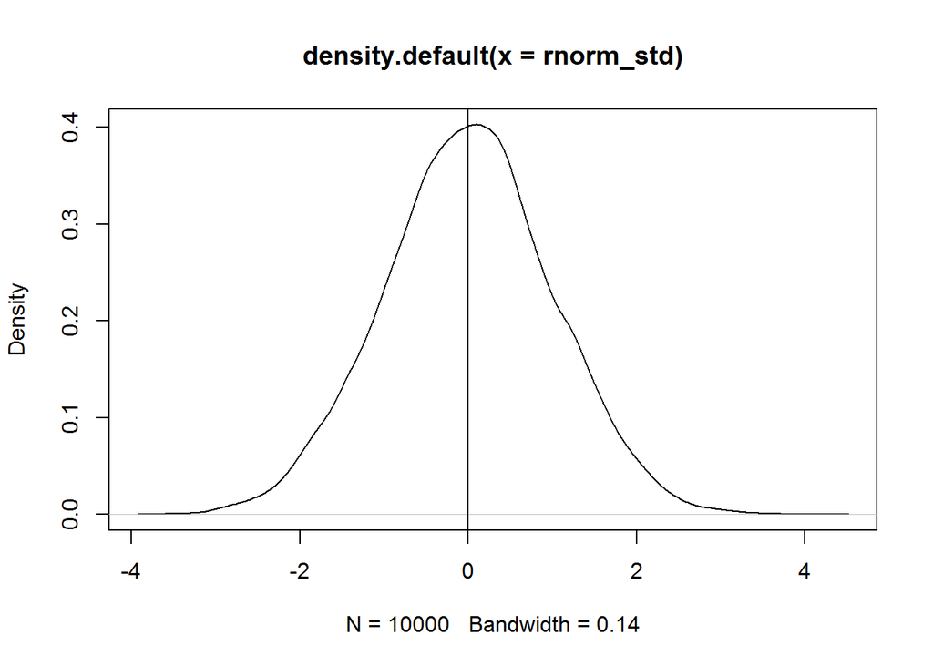

```r
# Plot rnorm_std distribution
plot(density(rnorm_std))
abline(v=mean(rnorm_std))
```

**→** A bell shape distribution. It will be look alike the shape of original data set but with different scale. The original data set is normal distribution which looks like a bell, after standardizing the data set rnorm_std will still be normal distribution.

**iii) What do we generally call distributions that are normal and standardized?**

**→** The standard normal distribution.

#### b. Create a standardized version of minday discussed in question 3.

```r
# standardize minday
minday_std <- standardized(minday)
```

**i) What should we expect the mean and standard deviation of minday_std to be, and why?**

```r
# compute the mean of minday_std
mean(minday_std)
```

```
## [1] -4.25589e-17
```

```r
# compute the standard deviation of minday_std
sd(minday_std)
```

```
## [1] 1
```

**→** The result of standardization is that the features will be rescaled to ensure the mean and the standard deviation to be 0 and 1, respectively.

As a result, we expect the mean of minday_std is 0 and the standard deviation is 1.

The little difference on mean above (close to 0 but not 0) is caused by the limitation of R in recording the number of digits.

**ii) What should the distribution of minday_std look like compared to minday, and why?**

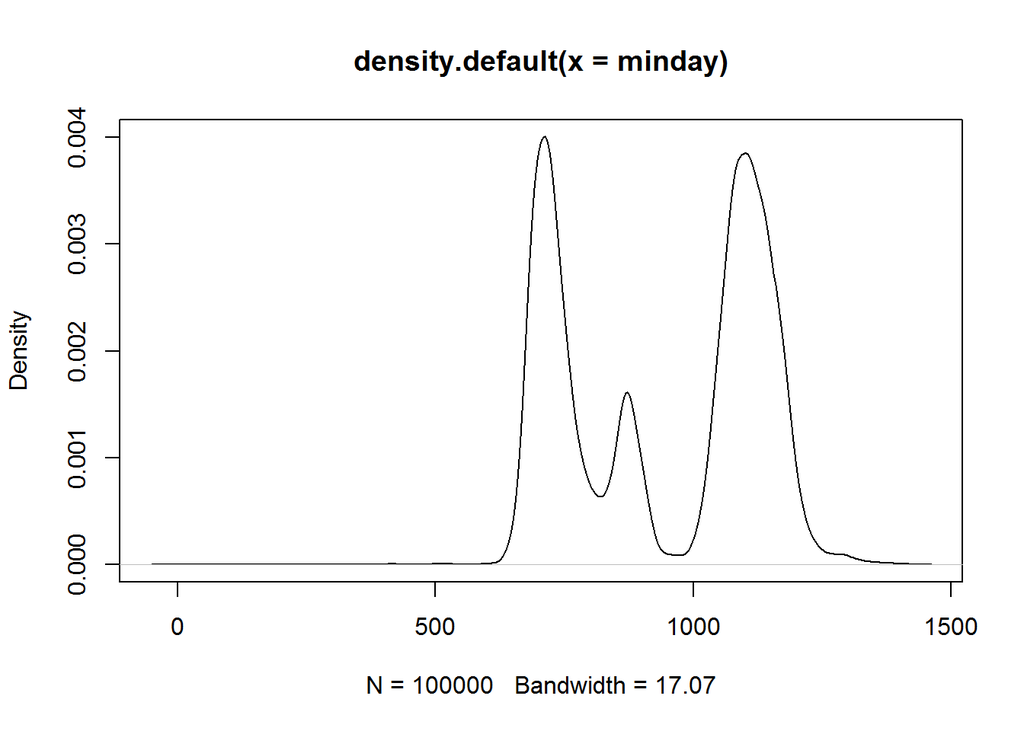

```r
# plot the original minday
plot(density(minday))
```

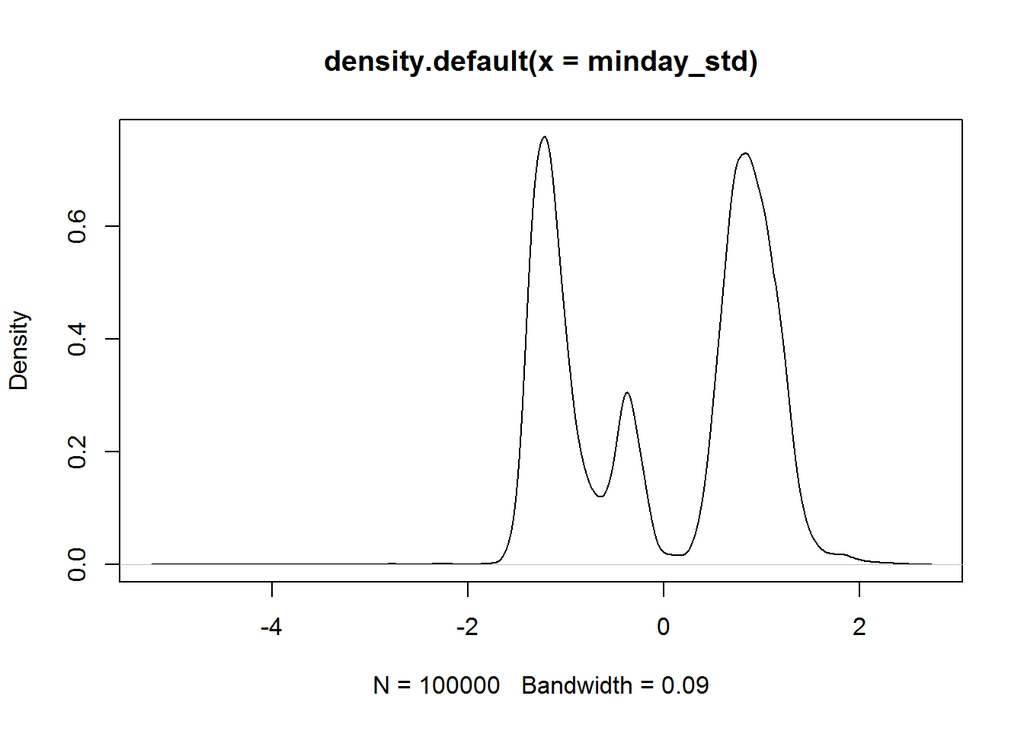

```r
# plot the standardized minday
plot(density(minday_std))
```

**→** the distribution shape of minday_std looks like the distribution shape of minday.

### 【Question 2】

Build visualize_sample_ci():

```r
visualize_sample_ci <- function(num_samples = 100, sample_size = 100,pop_size=10000, distr_func=rnorm, mean=20, sd=3) {

  # Simulate a large population
  population_data <- distr_func(pop_size, mean, sd)
  pop_mean <- mean(population_data)
  pop_sd <- sd(population_data)

  # Simulate samples
  samples <- replicate(num_samples,
                       sample(population_data,sample_size, replace=FALSE))

  # Calculate descriptives of samples
  sample_means = apply(samples, 2, FUN=mean)
  sample_stdevs = apply(samples, 2, FUN=sd)
  sample_stderrs <- sample_stdevs/sqrt(sample_size)
  ci95_low  <- sample_means - sample_stderrs*1.96
  ci95_high <- sample_means + sample_stderrs*1.96
  ci99_low  <- sample_means - sample_stderrs*2.58
  ci99_high <- sample_means + sample_stderrs*2.58

  # Visualize confidence intervals of all samples
  plot(NULL, xlim=c(pop_mean-(pop_sd/2), pop_mean+(pop_sd/2)),
       ylim=c(1,num_samples), ylab="Samples", xlab="Confidence Intervals")
  add_ci_segment(ci95_low, ci95_high, ci99_low, ci99_high,
                 sample_means, 1:num_samples, good=TRUE)

  # Visualize samples with CIs that don't include population mean
  bad = which(((ci95_low > pop_mean) | (ci95_high < pop_mean)) |
                ((ci99_low > pop_mean) | (ci99_high < pop_mean)))
  add_ci_segment(ci95_low[bad], ci95_high[bad], ci99_low[bad], ci99_high[bad],
                 sample_means[bad], bad, good=FALSE)

  # Draw true population mean
  abline(v=mean(population_data))
}

add_ci_segment <- function(ci95_low, ci95_high, ci99_low, ci99_high,
                           sample_means, indices, good=TRUE) {
  segment_colors <- list(c("lightcoral", "coral3", "coral4"),
                         c("lightskyblue", "skyblue3", "skyblue4"))
  color <- segment_colors[[as.integer(good)+1]]

  segments(ci99_low, indices, ci99_high, indices, lwd=3, col=color[1])
  segments(ci95_low, indices, ci95_high, indices, lwd=3, col=color[2])
  points(sample_means, indices, pch=18, cex=0.6, col=color[3])
}
```

#### a) Simulate 100 samples (each of size 100), from a normally distributed population of 10,000:

**visualize_sample_ci(num_samples = 100, sample_size = 100, pop_size=10000,distr_func=rnorm, mean=20, sd=3)**

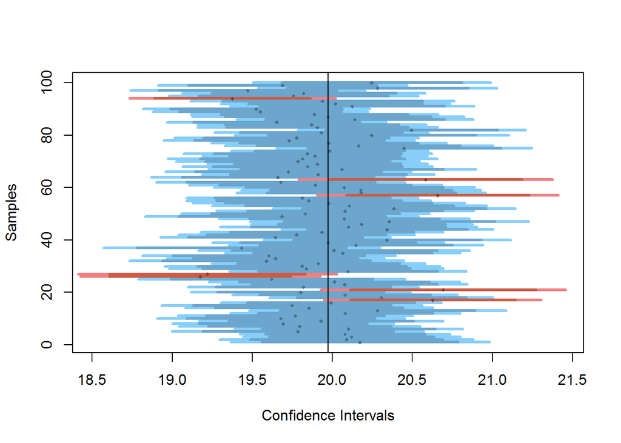

```r
visualize_sample_ci(num_samples = 100, sample_size = 100,
                    pop_size=10000, distr_func=rnorm, mean=20, sd=3)
```

**i) How many samples do we expect to NOT include the population mean in its 95% CI?**

**→** We expect about **5 samples** out of the 100 to not include the population mean in its 95% CI.

**ii) How many samples do we expect to NOT include the population mean in their 99% CI?**

**→** We expect about **1** samples to not include the population mean in its 99% CI.

#### b) Rerun the previous simulation with larger samples (sample_size=300):

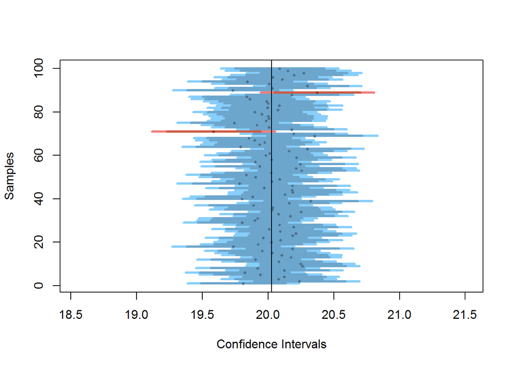

```r
# set sample_size = 300
visualize_sample_ci(num_samples = 100, sample_size = 300,
                    pop_size=10000, distr_func=rnorm, mean=20, sd=3)
```

**i) Now that the size of each sample has increased, do we expect their 95% and 99% CI to become wider or narrower than before?**

CI formula:

- 95% confidence interval of the mean : **(mean(x)-1.96σ)/sqrt(n)** to **(mean(x)+1.96σ)/sqrt(n)**
- 99% confidence interval of the mean : **(mean(x)-2.58σ)/sqrt(n)** to **(mean(x)+2.58σ)/sqrt(n)**

**→** According to CI formula, the interval will become **narrower** as sample size increases. We can observe this from the simulation above.

**ii) This time, how many samples (out of the 100) would we expect to NOT include the population mean in its 95% CI?**

**→** We expect about **5 samples** out of the 100 to not include the population mean in its 95% CI.

### 【Question 3】

Let’s prepare the data and look what it looks like before digging into the questions.

```r
# Read the file
bookings <- read.table("first_bookings_datetime_sample.txt", header=TRUE)
```

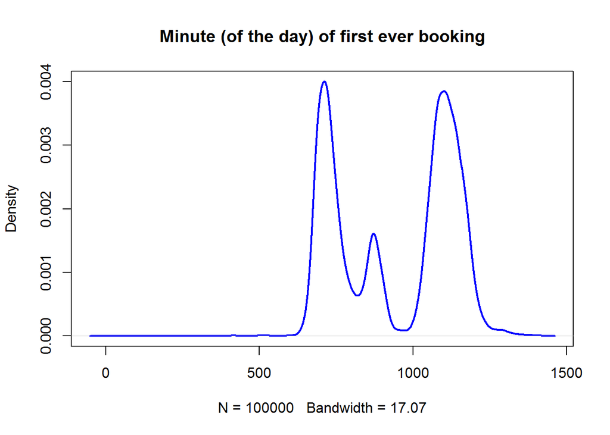

```r
# Transform the data form into minutes
hours  <- as.POSIXlt(bookings$datetime, format="%m/%d/%Y %H:%M")$hour
mins   <- as.POSIXlt(bookings$datetime, format="%m/%d/%Y %H:%M")$min
minday <- hours*60 + mins

# visualize the data
plot(density(minday), main="Minute (of the day) of first ever booking", col="blue", lwd=2)
```

#### a) What is the “average” booking time for new members making their first restaurant booking?

**i) Use traditional statistical methods to estimate the population mean of minday, its standard error, and the 95% confidence interval (CI) of the sampling means**

```r
# The sample mean
SplMean <- mean(minday)
SplMean
```

```
## [1] 942.4964
```

```r
# standard deviation of sample
Spl_sd <- sd(minday)
Spl_sd
```

```
## [1] 189.6631
```

```r
# standard error
sd_error <- Spl_sd/length(minday)
sd_error
```

```
## [1] 0.001896631
```

```r
# compute 95% CI of the population mean
PopMean <- SplMean+c(-1.96,1.96)*sd_error
PopMean
```

```
## [1] 942.4926 942.5001
```

**→**

Because we don’t know the true value of population mean and we just have the sample minday, we use minday to estimate the mean of population mean. The sample mean is 942.4964. In traditional statistical methods, we will say that the estimation of population mean of minday is 942.4964 (estimate from sample mean).

**ii) Bootstrap to produce 2000 new samples from the original sample**

```r
# create resample function
compute_sample_mean <- function(sample0) {
  resample <- sample(sample0, length(sample0), replace=TRUE)
  mean(resample)
}
```

```r
# bootstrapping
resamples_mean <- replicate(2000,compute_sample_mean(minday))
```

**iii) Visualize the means of the 2000 bootstrapped samples**

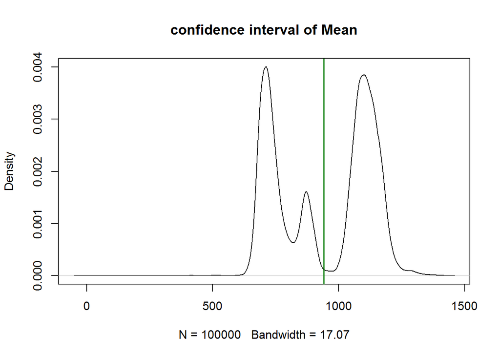

```r
# plot the original sample minday
plot(density(minday),main = "confidence interval of Mean")

# plot means of the 2000 bootstrapped samples
abline(v=resamples_mean, col=rgb(0.0, 0.4, 0.0, 0.01))
```

(Because data are too centralized in a small part, we change xlim=c(935, 950) so that we can zoom in to see the data.)

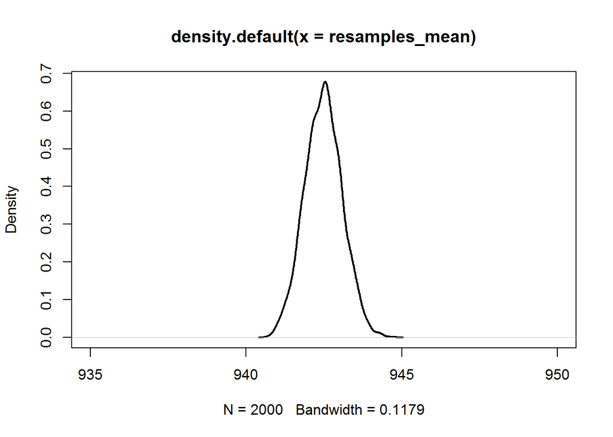

```r
# Plot the distribution of the 2000 bootstrapped samples means
plot(density(resamples_mean), lwd=2, xlim=c(935, 950))
```

We can see the distribution is a normal distribution.

**iv) Estimate the 95% CI of the bootstrapped means.**

```r
## Confidence intervals of the sampling means
quantile(resamples_mean, probs=c(0.025, 0.975))
```

```
##     2.5%    97.5%
## 941.3045 943.6644
```

#### b) By what time of day, have half the new members of the day already arrived at their restaurant?

```r
# Get the time that 50% new members already arrived
quantile(minday, probs = 0.5)
```

```
##  50%
## 1040
```

```r
# get the time and transform it back to the hour and minute
min_target <- unname(quantile(minday, probs = 0.5))
min_target/60
```

```
## [1] 17.33333
```

**i) Estimate the median of minday**

```r
# Get the midian of minday
quantile(minday, probs = 0.5)
```

```
##  50%
## 1040
```

**→** The midian of minday is 1040.

**ii) Visualize the medians of the 2000 bootstrapped samples**

```r
# create resample function and get the median of samples
compute_sample_median <- function(sample0) {
  resample <- sample(sample0, length(sample0), replace=TRUE)
  unname(quantile(resample, probs = 0.5))
}
```

```r
# 2000 bootstrapped samples
resamples_median <- replicate(2000,compute_sample_median(minday))
```

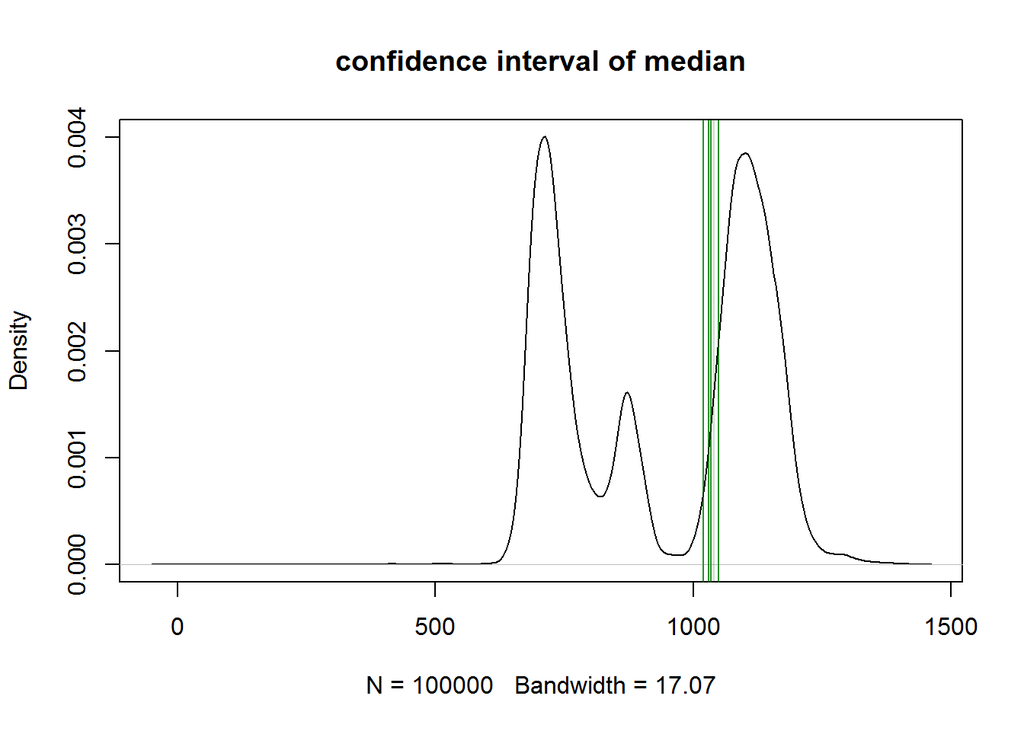

```r
# plot the original sample minday
plot(density(minday),main = "confidence interval of median")

# plot median of the 2000 bootstrapped samples
abline(v=resamples_median, col=rgb(0.0, 0.4, 0.0, 0.01))
```

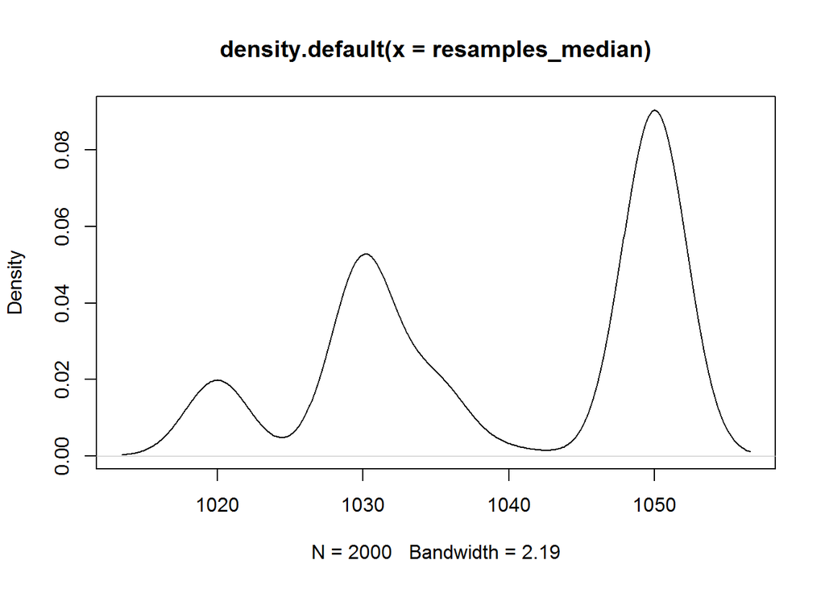

```r
# Plot the median of samples
plot(density(resamples_median))
```

**iii) Estimate the 95% CI of the bootstrapped medians.**

```r
# Get the 95% CI of the bootstrapped medians
quantile(resamples_median,probs = c(0.025,0.975))
```

```
##  2.5% 97.5%
##  1020  1050
```

**→** the 95% CI of the bootstrapped medians: (1020,1050)

(<sub>End</sub>)